# Anomaly Tests (1)

```python
%matplotlib inline
import requests
import numpy as np
import pandas as pd # pandas
import missingno as msno
import matplotlib.pyplot as plt # module for plotting
from statsmodels.tsa.seasonal import seasonal_decompose
import seaborn as sns
import datetime as dt # module for manipulating dates and times
from scipy import stats
from sklearn.cluster import KMeans
from pandas import Series
from sklearn.ensemble import IsolationForest
from sklearn import preprocessing
```

```python
df_orig = pd.read_excel('D:/Capstone/Cleaned files/Finalcleaneddata.xlsx', skip_blank_lines=True, delim_whitespace=True)
```

```python
#df_orig = df_orig.set_index('Timestamp')
df_orig
```

|  | Timestamp | CompAmps | Dat_SetPt | Discharge_Temp | DuctStatic_SetPt | DuctStatic | East_Temp | Econ_Pos | Fan_Hz_call | Mixed_Temp | ... | West_Temp | Outside_Air_Temp | Outside_Rel_Humidity | CompRelayStatus | Loader2Status | SupplyFanStatus | VAVEnableRelayStatus | VAVHeatEnableStatus | Loader1sTATUS | UnoccupiedLimit |
| --- | --- | --- | --- | --- | --- | --- | --- | --- | --- | --- | --- | --- | --- | --- | --- | --- | --- | --- | --- | --- | --- |
| 0 | 2016-08-01 00:00:00.000 | 0 | 55.0 | 75.7 | 1.00 | 0.91 | 73.2 | 5 | 20 | 77.7 | ... | 75.7 | 78.2 | 100.0 | 0 | 0 | 1 | 1 | 0 | 0 | 0 |
| 1 | 2016-08-01 01:00:00.000 | 0 | 55.0 | 75.4 | 1.00 | 0.08 | 77.6 | 0 | 20 | 77.6 | ... | 79.9 | 77.3 | 100.0 | 0 | 0 | 0 | 0 | 0 | 0 | 0 |
| 2 | 2016-08-01 02:00:00.000 | 0 | 55.0 | 77.0 | 1.00 | 0.08 | 78.5 | 0 | 20 | 77.6 | ... | 80.6 | 76.4 | 100.0 | 0 | 0 | 0 | 0 | 0 | 0 | 0 |
| 3 | 2016-08-01 03:00:00.000 | 60 | 55.0 | 54.0 | 1.00 | 1.00 | 70.6 | 0 | 20 | 77.6 | ... | 74.3 | 75.6 | 100.0 | 0 | 0 | 1 | 1 | 0 | 0 | 0 |
| 4 | 2016-08-01 04:00:00.000 | 47 | 55.0 | 59.7 | 1.00 | 1.06 | 71.2 | 0 | 20 | 77.9 | ... | 74.5 | 75.1 | 100.0 | 0 | 0 | 1 | 1 | 0 | 0 | 0 |
| 5 | 2016-08-01 05:00:00.000 | 60 | 56.0 | 52.7 | 1.00 | 1.09 | 70.0 | 5 | 68 | 75.7 | ... | 74.2 | 75.3 | 100.0 | 0 | 0 | 1 | 1 | 0 | 0 | 0 |
| 6 | 2016-08-01 06:00:00.000 | 61 | 55.7 | 53.2 | 1.00 | 1.07 | 70.3 | 5 | 64 | 75.5 | ... | 74.2 | 75.0 | 100.0 | 0 | 0 | 1 | 1 | 0 | 0 | 0 |
| 7 | 2016-08-01 07:00:00.000 | 47 | 55.7 | 57.1 | 1.00 | 1.06 | 70.3 | 5 | 65 | 75.1 | ... | 74.0 | 75.6 | 100.0 | 0 | 0 | 1 | 1 | 0 | 0 | 0 |
| 8 | 2016-08-01 08:00:00.000 | 61 | 55.9 | 55.4 | 1.00 | 1.10 | 70.4 | 5 | 64 | 74.8 | ... | 74.0 | 79.2 | 100.0 | 0 | 0 | 1 | 1 | 0 | 0 | 0 |
| 9 | 2016-08-01 09:00:00.000 | 61 | 55.2 | 54.8 | 1.00 | 1.06 | 70.3 | 5 | 64 | 75.4 | ... | 74.2 | 79.8 | 100.0 | 0 | 0 | 1 | 1 | 0 | 0 | 0 |
| 10 | 2016-08-01 10:00:00.000 | 61 | 55.0 | 53.7 | 1.00 | 1.01 | 70.3 | 5 | 63 | 75.4 | ... | 74.2 | 82.5 | 98.2 | 0 | 0 | 1 | 1 | 0 | 0 | 0 |
| 11 | 2016-08-01 11:00:00.000 | 61 | 55.0 | 53.6 | 1.00 | 1.01 | 70.2 | 5 | 64 | 75.7 | ... | 74.2 | 84.1 | 94.5 | 0 | 0 | 1 | 1 | 0 | 0 | 0 |
| 12 | 2016-08-01 12:00:00.000 | 62 | 55.0 | 54.1 | 1.00 | 1.04 | 70.3 | 5 | 64 | 75.5 | ... | 74.5 | 87.2 | 86.2 | 0 | 0 | 1 | 1 | 0 | 0 | 0 |
| 13 | 2016-08-01 13:00:00.000 | 62 | 55.3 | 54.0 | 1.00 | 1.01 | 69.8 | 5 | 64 | 75.7 | ... | 74.9 | 90.6 | 77.0 | 0 | 0 | 1 | 1 | 0 | 0 | 0 |
| 14 | 2016-08-01 14:00:00.000 | 61 | 55.0 | 53.9 | 1.00 | 1.00 | 70.1 | 5 | 64 | 75.6 | ... | 75.1 | 93.2 | 66.4 | 0 | 0 | 1 | 1 | 0 | 0 | 0 |
| 15 | 2016-08-01 15:00:00.000 | 61 | 55.0 | 54.1 | 1.00 | 0.98 | 70.4 | 5 | 65 | 75.5 | ... | 75.2 | 93.1 | 65.6 | 0 | 0 | 1 | 1 | 0 | 0 | 0 |
| 16 | 2016-08-01 16:00:00.000 | 61 | 55.0 | 53.7 | 1.00 | 1.07 | 70.3 | 5 | 66 | 75.7 | ... | 75.8 | 93.7 | 64.6 | 0 | 0 | 1 | 1 | 0 | 0 | 0 |
| 17 | 2016-08-01 17:00:00.000 | 61 | 55.0 | 54.2 | 1.00 | 0.99 | 70.4 | 5 | 65 | 75.7 | ... | 76.4 | 94.2 | 57.6 | 0 | 0 | 1 | 1 | 0 | 0 | 0 |
| 18 | 2016-08-01 18:00:00.000 | 0 | 55.0 | 77.0 | 1.00 | 0.92 | 73.7 | 5 | 67 | 76.0 | ... | 76.0 | 91.2 | 67.6 | 0 | 0 | 1 | 1 | 0 | 0 | 0 |
| 19 | 2016-08-01 19:00:00.000 | 0 | 55.0 | 78.0 | 1.00 | 0.08 | 76.8 | 0 | 20 | 77.1 | ... | 79.2 | 89.6 | 73.2 | 0 | 0 | 0 | 0 | 0 | 0 | 0 |
| 20 | 2016-08-01 20:00:00.000 | 0 | 55.0 | 79.2 | 1.00 | 0.08 | 77.5 | 0 | 20 | 77.2 | ... | 79.5 | 87.5 | 81.9 | 0 | 0 | 0 | 0 | 0 | 0 | 0 |
| 21 | 2016-08-01 21:00:00.000 | 0 | 55.0 | 79.6 | 1.00 | 0.08 | 78.0 | 0 | 20 | 77.6 | ... | 79.5 | 83.7 | 87.5 | 0 | 0 | 0 | 0 | 0 | 0 | 0 |
| 22 | 2016-08-01 22:00:00.000 | 0 | 55.0 | 79.2 | 1.00 | 0.08 | 78.4 | 0 | 20 | 77.6 | ... | 79.5 | 81.4 | 96.3 | 0 | 0 | 0 | 0 | 0 | 0 | 0 |
| 23 | 2016-08-01 23:00:00.000 | 0 | 55.0 | 78.2 | 1.00 | 0.08 | 78.2 | 0 | 20 | 77.6 | ... | 79.4 | 79.8 | 100.0 | 0 | 0 | 0 | 0 | 0 | 0 | 0 |
| 24 | 2016-08-02 00:00:00.000 | 0 | 55.0 | 77.6 | 1.00 | 0.08 | 78.2 | 0 | 20 | 77.4 | ... | 79.3 | 78.9 | 99.9 | 0 | 0 | 0 | 0 | 0 | 0 | 0 |
| 25 | 2016-08-02 01:00:00.000 | 0 | 55.0 | 77.1 | 1.00 | 0.08 | 78.4 | 0 | 20 | 77.2 | ... | 79.3 | 78.8 | 100.0 | 0 | 0 | 0 | 0 | 0 | 0 | 0 |
| 26 | 2016-08-02 02:00:00.000 | 0 | 55.0 | 77.1 | 1.00 | 0.08 | 78.4 | 0 | 20 | 77.1 | ... | 79.2 | 77.3 | 100.0 | 0 | 0 | 0 | 0 | 0 | 0 | 0 |
| 27 | 2016-08-02 03:00:00.000 | 47 | 55.0 | 58.6 | 1.00 | 1.04 | 70.8 | 0 | 20 | 77.2 | ... | 73.9 | 76.1 | 100.0 | 0 | 0 | 1 | 1 | 0 | 0 | 0 |
| 28 | 2016-08-02 04:00:00.000 | 47 | 55.0 | 60.9 | 1.00 | 0.98 | 72.9 | 0 | 20 | 77.3 | ... | 75.0 | 75.9 | 100.0 | 0 | 0 | 1 | 1 | 0 | 0 | 0 |
| 29 | 2016-08-02 05:00:00.000 | 47 | 55.6 | 58.0 | 1.00 | 1.04 | 71.2 | 5 | 67 | 75.9 | ... | 73.5 | 75.5 | 100.0 | 0 | 0 | 1 | 1 | 0 | 0 | 0 |
| ... | ... | ... | ... | ... | ... | ... | ... | ... | ... | ... | ... | ... | ... | ... | ... | ... | ... | ... | ... | ... | ... |
| 8598 | 2017-07-25 19:59:59.998 | 0 | 55.0 | 77.2 | 1.25 | 0.08 | 76.8 | 0 | 20 | 77.5 | ... | 77.0 | 77.3 | 52.0 | 0 | 0 | 0 | 0 | 0 | 0 | 0 |
| 8599 | 2017-07-25 20:59:59.998 | 0 | 55.0 | 77.5 | 1.25 | 0.08 | 76.7 | 0 | 20 | 77.6 | ... | 77.0 | 75.3 | 56.0 | 0 | 0 | 0 | 0 | 0 | 0 | 0 |
| 8600 | 2017-07-25 21:59:59.998 | 0 | 55.0 | 77.3 | 1.25 | 0.08 | 77.2 | 0 | 20 | 77.3 | ... | 76.8 | 73.9 | 62.0 | 0 | 0 | 0 | 0 | 0 | 0 | 0 |
| 8601 | 2017-07-25 22:59:59.998 | 0 | 55.0 | 77.1 | 1.25 | 0.09 | 77.2 | 0 | 20 | 77.2 | ... | 76.8 | 72.7 | 64.0 | 0 | 0 | 0 | 0 | 0 | 0 | 0 |
| 8602 | 2017-07-25 23:59:59.998 | 0 | 55.0 | 76.9 | 1.25 | 0.09 | 77.0 | 0 | 20 | 77.5 | ... | 76.7 | 71.8 | 66.0 | 0 | 0 | 0 | 0 | 0 | 0 | 0 |
| 8603 | 2017-07-26 00:59:59.998 | 0 | 55.0 | 77.3 | 1.25 | 0.09 | 77.1 | 0 | 20 | 77.8 | ... | 76.6 | 70.6 | 69.0 | 0 | 0 | 0 | 0 | 0 | 0 | 0 |
| 8604 | 2017-07-26 01:59:59.998 | 0 | 55.0 | 77.8 | 1.25 | 0.09 | 77.4 | 0 | 20 | 78.6 | ... | 76.6 | 69.5 | 69.0 | 0 | 0 | 0 | 0 | 0 | 0 | 0 |
| 8605 | 2017-07-26 02:59:59.998 | 0 | 55.0 | 78.2 | 1.25 | 0.09 | 77.3 | 0 | 20 | 78.8 | ... | 76.5 | 68.4 | 71.0 | 0 | 0 | 0 | 0 | 0 | 0 | 0 |
| 8606 | 2017-07-26 03:59:59.998 | 0 | 55.0 | 78.6 | 1.25 | 0.09 | 77.5 | 0 | 20 | 79.2 | ... | 76.5 | 67.6 | 73.0 | 0 | 0 | 0 | 0 | 0 | 0 | 0 |
| 8607 | 2017-07-26 04:59:59.998 | 47 | 55.0 | 63.5 | 1.25 | 0.87 | 77.8 | 0 | 61 | 79.8 | ... | 76.5 | 66.8 | 76.0 | 1 | 0 | 1 | 1 | 1 | 0 | 0 |
| 8608 | 2017-07-26 05:59:59.998 | 58 | 58.5 | 53.7 | 1.25 | 1.48 | 71.6 | 0 | 63 | 76.3 | ... | 73.5 | 66.2 | 81.0 | 1 | 0 | 1 | 1 | 1 | 1 | 0 |
| 8609 | 2017-07-26 06:59:59.998 | 0 | 57.8 | 74.0 | 1.25 | 1.13 | 72.7 | 5 | 62 | 76.4 | ... | 73.4 | 71.2 | 84.0 | 0 | 0 | 1 | 1 | 0 | 0 | 0 |
| 8610 | 2017-07-26 07:59:59.998 | 46 | 59.0 | 58.7 | 1.25 | 1.15 | 70.8 | 5 | 60 | 76.1 | ... | 73.1 | 79.4 | 84.0 | 1 | 0 | 1 | 1 | 0 | 0 | 0 |
| 8611 | 2017-07-26 08:59:59.998 | 46 | 59.1 | 58.1 | 1.25 | 1.15 | 70.1 | 5 | 59 | 76.1 | ... | 73.2 | 81.6 | 82.0 | 1 | 0 | 1 | 1 | 0 | 0 | 0 |
| 8612 | 2017-07-26 09:59:59.998 | 46 | 58.0 | 59.0 | 1.25 | 1.23 | 70.6 | 5 | 60 | 76.4 | ... | 73.5 | 78.7 | 76.0 | 1 | 0 | 1 | 1 | 0 | 0 | 0 |
| 8613 | 2017-07-26 10:59:59.998 | 46 | 57.9 | 58.9 | 1.25 | 1.33 | 71.1 | 5 | 60 | 76.4 | ... | 73.8 | 80.8 | 74.0 | 1 | 0 | 1 | 1 | 0 | 0 | 0 |
| 8614 | 2017-07-26 11:59:59.998 | 47 | 57.9 | 58.7 | 1.25 | 1.25 | 71.0 | 5 | 59 | 76.4 | ... | 73.8 | 82.8 | 60.0 | 1 | 0 | 1 | 1 | 0 | 0 | 0 |
| 8615 | 2017-07-26 12:59:59.998 | 47 | 58.1 | 58.6 | 1.25 | 1.29 | 71.0 | 5 | 60 | 76.3 | ... | 74.1 | 85.2 | 54.0 | 1 | 0 | 1 | 1 | 0 | 0 | 0 |
| 8616 | 2017-07-26 13:59:59.998 | 47 | 58.2 | 58.5 | 1.25 | 1.28 | 70.9 | 5 | 60 | 76.1 | ... | 74.0 | 86.8 | 46.0 | 1 | 0 | 1 | 1 | 0 | 0 | 0 |
| 8617 | 2017-07-26 14:59:59.998 | 47 | 58.4 | 58.6 | 1.25 | 1.26 | 70.9 | 5 | 59 | 76.1 | ... | 73.9 | 85.3 | 49.0 | 1 | 0 | 1 | 1 | 0 | 0 | 0 |
| 8618 | 2017-07-26 15:59:59.998 | 47 | 58.4 | 58.4 | 1.25 | 1.27 | 70.5 | 5 | 61 | 76.1 | ... | 75.1 | 88.1 | 51.0 | 1 | 0 | 1 | 1 | 0 | 0 | 0 |
| 8619 | 2017-07-26 16:59:59.998 | 46 | 58.4 | 58.7 | 1.25 | 1.31 | 70.6 | 5 | 62 | 76.1 | ... | 76.0 | 90.2 | 48.0 | 1 | 0 | 1 | 1 | 0 | 0 | 0 |
| 8620 | 2017-07-26 17:59:59.998 | 0 | 55.6 | 78.0 | 1.25 | 1.07 | 74.3 | 5 | 64 | 77.1 | ... | 76.6 | 93.0 | 46.0 | 0 | 0 | 1 | 1 | 0 | 0 | 0 |
| 8621 | 2017-07-26 18:59:59.998 | 0 | 55.0 | 77.4 | 1.25 | 0.08 | 76.1 | 0 | 20 | 78.2 | ... | 77.4 | 87.4 | 46.0 | 0 | 0 | 0 | 0 | 0 | 0 | 0 |
| 8622 | 2017-07-26 19:59:59.998 | 0 | 55.0 | 78.3 | 1.25 | 0.08 | 76.7 | 0 | 20 | 78.6 | ... | 77.3 | 84.0 | 46.0 | 0 | 0 | 0 | 0 | 0 | 0 | 0 |
| 8623 | 2017-07-26 20:59:59.998 | 0 | 55.0 | 78.9 | 1.25 | 0.08 | 77.1 | 0 | 20 | 78.6 | ... | 77.1 | 80.3 | 67.0 | 0 | 0 | 0 | 0 | 0 | 0 | 0 |
| 8624 | 2017-07-26 21:59:59.998 | 0 | 55.0 | 78.4 | 1.25 | 0.09 | 77.0 | 0 | 20 | 78.2 | ... | 77.0 | 78.5 | 69.0 | 0 | 0 | 0 | 0 | 0 | 0 | 0 |
| 8625 | 2017-07-26 22:59:59.998 | 0 | 55.0 | 78.4 | 1.25 | 0.08 | 77.1 | 0 | 20 | 78.2 | ... | 76.9 | 76.7 | 77.0 | 0 | 0 | 0 | 0 | 0 | 0 | 0 |
| 8626 | 2017-07-26 23:59:59.998 | 0 | 55.0 | 77.9 | 1.25 | 0.09 | 77.4 | 0 | 20 | 78.0 | ... | 76.8 | 75.5 | 85.0 | 0 | 0 | 0 | 0 | 0 | 0 | 0 |
| 8627 | 2017-07-27 00:59:59.998 | 0 | 55.0 | 77.6 | 1.25 | 0.08 | 76.9 | 0 | 20 | 78.0 | ... | 76.8 | 74.7 | 88.0 | 0 | 0 | 0 | 0 | 0 | 0 | 0 |

8628 rows × 25 columns

```python
df_orig.Econ_Pos.skew()
```

```
3.340699697907706
```

#### Transform Economizer Position and replace it in the AHU dataframe

#### The domain for log is strictly greater than 0. As x approaches 0, y approaches negative infinity. In other words, 0 is excluded from the domain.Many of my data points are 0 because many economizer values are 0. For a quick fix, we added 1 to each data point. This works well since the log of 1 is 0. Furthermore, the same spread is retained since all points are increased by 1.

```python
#Log Function + 1
df_orig['log_econ_pos'] = np.log(df_orig.Econ_Pos+1)
df_new = df_orig.drop(['Econ_Pos'], axis=1)
df_new
```

|  | Timestamp | CompAmps | Dat_SetPt | Discharge_Temp | DuctStatic_SetPt | DuctStatic | East_Temp | Fan_Hz_call | Mixed_Temp | NorthTemp | ... | Outside_Air_Temp | Outside_Rel_Humidity | CompRelayStatus | Loader2Status | SupplyFanStatus | VAVEnableRelayStatus | VAVHeatEnableStatus | Loader1sTATUS | UnoccupiedLimit | log_econ_pos |
| --- | --- | --- | --- | --- | --- | --- | --- | --- | --- | --- | --- | --- | --- | --- | --- | --- | --- | --- | --- | --- | --- |
| 0 | 2016-08-01 00:00:00.000 | 0 | 55.0 | 75.7 | 1.00 | 0.91 | 73.2 | 20 | 77.7 | 77.5 | ... | 78.2 | 100.0 | 0 | 0 | 1 | 1 | 0 | 0 | 0 | 1.791759 |
| 1 | 2016-08-01 01:00:00.000 | 0 | 55.0 | 75.4 | 1.00 | 0.08 | 77.6 | 20 | 77.6 | 77.4 | ... | 77.3 | 100.0 | 0 | 0 | 0 | 0 | 0 | 0 | 0 | 0.000000 |
| 2 | 2016-08-01 02:00:00.000 | 0 | 55.0 | 77.0 | 1.00 | 0.08 | 78.5 | 20 | 77.6 | 77.4 | ... | 76.4 | 100.0 | 0 | 0 | 0 | 0 | 0 | 0 | 0 | 0.000000 |
| 3 | 2016-08-01 03:00:00.000 | 60 | 55.0 | 54.0 | 1.00 | 1.00 | 70.6 | 20 | 77.6 | 77.4 | ... | 75.6 | 100.0 | 0 | 0 | 1 | 1 | 0 | 0 | 0 | 0.000000 |
| 4 | 2016-08-01 04:00:00.000 | 47 | 55.0 | 59.7 | 1.00 | 1.06 | 71.2 | 20 | 77.9 | 77.3 | ... | 75.1 | 100.0 | 0 | 0 | 1 | 1 | 0 | 0 | 0 | 0.000000 |
| 5 | 2016-08-01 05:00:00.000 | 60 | 56.0 | 52.7 | 1.00 | 1.09 | 70.0 | 68 | 75.7 | 76.6 | ... | 75.3 | 100.0 | 0 | 0 | 1 | 1 | 0 | 0 | 0 | 1.791759 |
| 6 | 2016-08-01 06:00:00.000 | 61 | 55.7 | 53.2 | 1.00 | 1.07 | 70.3 | 64 | 75.5 | 74.7 | ... | 75.0 | 100.0 | 0 | 0 | 1 | 1 | 0 | 0 | 0 | 1.791759 |
| 7 | 2016-08-01 07:00:00.000 | 47 | 55.7 | 57.1 | 1.00 | 1.06 | 70.3 | 65 | 75.1 | 74.8 | ... | 75.6 | 100.0 | 0 | 0 | 1 | 1 | 0 | 0 | 0 | 1.791759 |
| 8 | 2016-08-01 08:00:00.000 | 61 | 55.9 | 55.4 | 1.00 | 1.10 | 70.4 | 64 | 74.8 | 74.8 | ... | 79.2 | 100.0 | 0 | 0 | 1 | 1 | 0 | 0 | 0 | 1.791759 |
| 9 | 2016-08-01 09:00:00.000 | 61 | 55.2 | 54.8 | 1.00 | 1.06 | 70.3 | 64 | 75.4 | 75.1 | ... | 79.8 | 100.0 | 0 | 0 | 1 | 1 | 0 | 0 | 0 | 1.791759 |
| 10 | 2016-08-01 10:00:00.000 | 61 | 55.0 | 53.7 | 1.00 | 1.01 | 70.3 | 63 | 75.4 | 75.4 | ... | 82.5 | 98.2 | 0 | 0 | 1 | 1 | 0 | 0 | 0 | 1.791759 |
| 11 | 2016-08-01 11:00:00.000 | 61 | 55.0 | 53.6 | 1.00 | 1.01 | 70.2 | 64 | 75.7 | 75.4 | ... | 84.1 | 94.5 | 0 | 0 | 1 | 1 | 0 | 0 | 0 | 1.791759 |
| 12 | 2016-08-01 12:00:00.000 | 62 | 55.0 | 54.1 | 1.00 | 1.04 | 70.3 | 64 | 75.5 | 75.4 | ... | 87.2 | 86.2 | 0 | 0 | 1 | 1 | 0 | 0 | 0 | 1.791759 |
| 13 | 2016-08-01 13:00:00.000 | 62 | 55.3 | 54.0 | 1.00 | 1.01 | 69.8 | 64 | 75.7 | 75.0 | ... | 90.6 | 77.0 | 0 | 0 | 1 | 1 | 0 | 0 | 0 | 1.791759 |
| 14 | 2016-08-01 14:00:00.000 | 61 | 55.0 | 53.9 | 1.00 | 1.00 | 70.1 | 64 | 75.6 | 74.8 | ... | 93.2 | 66.4 | 0 | 0 | 1 | 1 | 0 | 0 | 0 | 1.791759 |
| 15 | 2016-08-01 15:00:00.000 | 61 | 55.0 | 54.1 | 1.00 | 0.98 | 70.4 | 65 | 75.5 | 75.1 | ... | 93.1 | 65.6 | 0 | 0 | 1 | 1 | 0 | 0 | 0 | 1.791759 |
| 16 | 2016-08-01 16:00:00.000 | 61 | 55.0 | 53.7 | 1.00 | 1.07 | 70.3 | 66 | 75.7 | 75.2 | ... | 93.7 | 64.6 | 0 | 0 | 1 | 1 | 0 | 0 | 0 | 1.791759 |
| 17 | 2016-08-01 17:00:00.000 | 61 | 55.0 | 54.2 | 1.00 | 0.99 | 70.4 | 65 | 75.7 | 74.6 | ... | 94.2 | 57.6 | 0 | 0 | 1 | 1 | 0 | 0 | 0 | 1.791759 |
| 18 | 2016-08-01 18:00:00.000 | 0 | 55.0 | 77.0 | 1.00 | 0.92 | 73.7 | 67 | 76.0 | 74.6 | ... | 91.2 | 67.6 | 0 | 0 | 1 | 1 | 0 | 0 | 0 | 1.791759 |
| 19 | 2016-08-01 19:00:00.000 | 0 | 55.0 | 78.0 | 1.00 | 0.08 | 76.8 | 20 | 77.1 | 76.1 | ... | 89.6 | 73.2 | 0 | 0 | 0 | 0 | 0 | 0 | 0 | 0.000000 |
| 20 | 2016-08-01 20:00:00.000 | 0 | 55.0 | 79.2 | 1.00 | 0.08 | 77.5 | 20 | 77.2 | 76.6 | ... | 87.5 | 81.9 | 0 | 0 | 0 | 0 | 0 | 0 | 0 | 0.000000 |
| 21 | 2016-08-01 21:00:00.000 | 0 | 55.0 | 79.6 | 1.00 | 0.08 | 78.0 | 20 | 77.6 | 76.8 | ... | 83.7 | 87.5 | 0 | 0 | 0 | 0 | 0 | 0 | 0 | 0.000000 |
| 22 | 2016-08-01 22:00:00.000 | 0 | 55.0 | 79.2 | 1.00 | 0.08 | 78.4 | 20 | 77.6 | 77.0 | ... | 81.4 | 96.3 | 0 | 0 | 0 | 0 | 0 | 0 | 0 | 0.000000 |
| 23 | 2016-08-01 23:00:00.000 | 0 | 55.0 | 78.2 | 1.00 | 0.08 | 78.2 | 20 | 77.6 | 77.1 | ... | 79.8 | 100.0 | 0 | 0 | 0 | 0 | 0 | 0 | 0 | 0.000000 |
| 24 | 2016-08-02 00:00:00.000 | 0 | 55.0 | 77.6 | 1.00 | 0.08 | 78.2 | 20 | 77.4 | 77.2 | ... | 78.9 | 99.9 | 0 | 0 | 0 | 0 | 0 | 0 | 0 | 0.000000 |
| 25 | 2016-08-02 01:00:00.000 | 0 | 55.0 | 77.1 | 1.00 | 0.08 | 78.4 | 20 | 77.2 | 77.2 | ... | 78.8 | 100.0 | 0 | 0 | 0 | 0 | 0 | 0 | 0 | 0.000000 |
| 26 | 2016-08-02 02:00:00.000 | 0 | 55.0 | 77.1 | 1.00 | 0.08 | 78.4 | 20 | 77.1 | 77.2 | ... | 77.3 | 100.0 | 0 | 0 | 0 | 0 | 0 | 0 | 0 | 0.000000 |
| 27 | 2016-08-02 03:00:00.000 | 47 | 55.0 | 58.6 | 1.00 | 1.04 | 70.8 | 20 | 77.2 | 77.2 | ... | 76.1 | 100.0 | 0 | 0 | 1 | 1 | 0 | 0 | 0 | 0.000000 |
| 28 | 2016-08-02 04:00:00.000 | 47 | 55.0 | 60.9 | 1.00 | 0.98 | 72.9 | 20 | 77.3 | 77.3 | ... | 75.9 | 100.0 | 0 | 0 | 1 | 1 | 0 | 0 | 0 | 0.000000 |
| 29 | 2016-08-02 05:00:00.000 | 47 | 55.6 | 58.0 | 1.00 | 1.04 | 71.2 | 67 | 75.9 | 76.9 | ... | 75.5 | 100.0 | 0 | 0 | 1 | 1 | 0 | 0 | 0 | 1.791759 |
| ... | ... | ... | ... | ... | ... | ... | ... | ... | ... | ... | ... | ... | ... | ... | ... | ... | ... | ... | ... | ... | ... |
| 8598 | 2017-07-25 19:59:59.998 | 0 | 55.0 | 77.2 | 1.25 | 0.08 | 76.8 | 20 | 77.5 | 76.6 | ... | 77.3 | 52.0 | 0 | 0 | 0 | 0 | 0 | 0 | 0 | 0.000000 |
| 8599 | 2017-07-25 20:59:59.998 | 0 | 55.0 | 77.5 | 1.25 | 0.08 | 76.7 | 20 | 77.6 | 76.8 | ... | 75.3 | 56.0 | 0 | 0 | 0 | 0 | 0 | 0 | 0 | 0.000000 |
| 8600 | 2017-07-25 21:59:59.998 | 0 | 55.0 | 77.3 | 1.25 | 0.08 | 77.2 | 20 | 77.3 | 77.0 | ... | 73.9 | 62.0 | 0 | 0 | 0 | 0 | 0 | 0 | 0 | 0.000000 |
| 8601 | 2017-07-25 22:59:59.998 | 0 | 55.0 | 77.1 | 1.25 | 0.09 | 77.2 | 20 | 77.2 | 77.0 | ... | 72.7 | 64.0 | 0 | 0 | 0 | 0 | 0 | 0 | 0 | 0.000000 |
| 8602 | 2017-07-25 23:59:59.998 | 0 | 55.0 | 76.9 | 1.25 | 0.09 | 77.0 | 20 | 77.5 | 77.0 | ... | 71.8 | 66.0 | 0 | 0 | 0 | 0 | 0 | 0 | 0 | 0.000000 |
| 8603 | 2017-07-26 00:59:59.998 | 0 | 55.0 | 77.3 | 1.25 | 0.09 | 77.1 | 20 | 77.8 | 77.1 | ... | 70.6 | 69.0 | 0 | 0 | 0 | 0 | 0 | 0 | 0 | 0.000000 |
| 8604 | 2017-07-26 01:59:59.998 | 0 | 55.0 | 77.8 | 1.25 | 0.09 | 77.4 | 20 | 78.6 | 77.1 | ... | 69.5 | 69.0 | 0 | 0 | 0 | 0 | 0 | 0 | 0 | 0.000000 |
| 8605 | 2017-07-26 02:59:59.998 | 0 | 55.0 | 78.2 | 1.25 | 0.09 | 77.3 | 20 | 78.8 | 77.1 | ... | 68.4 | 71.0 | 0 | 0 | 0 | 0 | 0 | 0 | 0 | 0.000000 |
| 8606 | 2017-07-26 03:59:59.998 | 0 | 55.0 | 78.6 | 1.25 | 0.09 | 77.5 | 20 | 79.2 | 77.2 | ... | 67.6 | 73.0 | 0 | 0 | 0 | 0 | 0 | 0 | 0 | 0.000000 |
| 8607 | 2017-07-26 04:59:59.998 | 47 | 55.0 | 63.5 | 1.25 | 0.87 | 77.8 | 61 | 79.8 | 77.2 | ... | 66.8 | 76.0 | 1 | 0 | 1 | 1 | 1 | 0 | 0 | 0.000000 |
| 8608 | 2017-07-26 05:59:59.998 | 58 | 58.5 | 53.7 | 1.25 | 1.48 | 71.6 | 63 | 76.3 | 74.8 | ... | 66.2 | 81.0 | 1 | 0 | 1 | 1 | 1 | 1 | 0 | 0.000000 |
| 8609 | 2017-07-26 06:59:59.998 | 0 | 57.8 | 74.0 | 1.25 | 1.13 | 72.7 | 62 | 76.4 | 74.6 | ... | 71.2 | 84.0 | 0 | 0 | 1 | 1 | 0 | 0 | 0 | 1.791759 |
| 8610 | 2017-07-26 07:59:59.998 | 46 | 59.0 | 58.7 | 1.25 | 1.15 | 70.8 | 60 | 76.1 | 74.7 | ... | 79.4 | 84.0 | 1 | 0 | 1 | 1 | 0 | 0 | 0 | 1.791759 |
| 8611 | 2017-07-26 08:59:59.998 | 46 | 59.1 | 58.1 | 1.25 | 1.15 | 70.1 | 59 | 76.1 | 74.8 | ... | 81.6 | 82.0 | 1 | 0 | 1 | 1 | 0 | 0 | 0 | 1.791759 |
| 8612 | 2017-07-26 09:59:59.998 | 46 | 58.0 | 59.0 | 1.25 | 1.23 | 70.6 | 60 | 76.4 | 75.1 | ... | 78.7 | 76.0 | 1 | 0 | 1 | 1 | 0 | 0 | 0 | 1.791759 |
| 8613 | 2017-07-26 10:59:59.998 | 46 | 57.9 | 58.9 | 1.25 | 1.33 | 71.1 | 60 | 76.4 | 75.4 | ... | 80.8 | 74.0 | 1 | 0 | 1 | 1 | 0 | 0 | 0 | 1.791759 |
| 8614 | 2017-07-26 11:59:59.998 | 47 | 57.9 | 58.7 | 1.25 | 1.25 | 71.0 | 59 | 76.4 | 75.6 | ... | 82.8 | 60.0 | 1 | 0 | 1 | 1 | 0 | 0 | 0 | 1.791759 |
| 8615 | 2017-07-26 12:59:59.998 | 47 | 58.1 | 58.6 | 1.25 | 1.29 | 71.0 | 60 | 76.3 | 75.6 | ... | 85.2 | 54.0 | 1 | 0 | 1 | 1 | 0 | 0 | 0 | 1.791759 |
| 8616 | 2017-07-26 13:59:59.998 | 47 | 58.2 | 58.5 | 1.25 | 1.28 | 70.9 | 60 | 76.1 | 75.8 | ... | 86.8 | 46.0 | 1 | 0 | 1 | 1 | 0 | 0 | 0 | 1.791759 |
| 8617 | 2017-07-26 14:59:59.998 | 47 | 58.4 | 58.6 | 1.25 | 1.26 | 70.9 | 59 | 76.1 | 75.9 | ... | 85.3 | 49.0 | 1 | 0 | 1 | 1 | 0 | 0 | 0 | 1.791759 |
| 8618 | 2017-07-26 15:59:59.998 | 47 | 58.4 | 58.4 | 1.25 | 1.27 | 70.5 | 61 | 76.1 | 75.8 | ... | 88.1 | 51.0 | 1 | 0 | 1 | 1 | 0 | 0 | 0 | 1.791759 |
| 8619 | 2017-07-26 16:59:59.998 | 46 | 58.4 | 58.7 | 1.25 | 1.31 | 70.6 | 62 | 76.1 | 75.7 | ... | 90.2 | 48.0 | 1 | 0 | 1 | 1 | 0 | 0 | 0 | 1.791759 |
| 8620 | 2017-07-26 17:59:59.998 | 0 | 55.6 | 78.0 | 1.25 | 1.07 | 74.3 | 64 | 77.1 | 75.7 | ... | 93.0 | 46.0 | 0 | 0 | 1 | 1 | 0 | 0 | 0 | 1.791759 |
| 8621 | 2017-07-26 18:59:59.998 | 0 | 55.0 | 77.4 | 1.25 | 0.08 | 76.1 | 20 | 78.2 | 76.5 | ... | 87.4 | 46.0 | 0 | 0 | 0 | 0 | 0 | 0 | 0 | 0.000000 |
| 8622 | 2017-07-26 19:59:59.998 | 0 | 55.0 | 78.3 | 1.25 | 0.08 | 76.7 | 20 | 78.6 | 76.9 | ... | 84.0 | 46.0 | 0 | 0 | 0 | 0 | 0 | 0 | 0 | 0.000000 |
| 8623 | 2017-07-26 20:59:59.998 | 0 | 55.0 | 78.9 | 1.25 | 0.08 | 77.1 | 20 | 78.6 | 77.2 | ... | 80.3 | 67.0 | 0 | 0 | 0 | 0 | 0 | 0 | 0 | 0.000000 |
| 8624 | 2017-07-26 21:59:59.998 | 0 | 55.0 | 78.4 | 1.25 | 0.09 | 77.0 | 20 | 78.2 | 77.3 | ... | 78.5 | 69.0 | 0 | 0 | 0 | 0 | 0 | 0 | 0 | 0.000000 |
| 8625 | 2017-07-26 22:59:59.998 | 0 | 55.0 | 78.4 | 1.25 | 0.08 | 77.1 | 20 | 78.2 | 77.4 | ... | 76.7 | 77.0 | 0 | 0 | 0 | 0 | 0 | 0 | 0 | 0.000000 |
| 8626 | 2017-07-26 23:59:59.998 | 0 | 55.0 | 77.9 | 1.25 | 0.09 | 77.4 | 20 | 78.0 | 77.4 | ... | 75.5 | 85.0 | 0 | 0 | 0 | 0 | 0 | 0 | 0 | 0.000000 |
| 8627 | 2017-07-27 00:59:59.998 | 0 | 55.0 | 77.6 | 1.25 | 0.08 | 76.9 | 20 | 78.0 | 77.2 | ... | 74.7 | 88.0 | 0 | 0 | 0 | 0 | 0 | 0 | 0 | 0.000000 |

8628 rows × 25 columns

```python
df_orig['log_econ_pos'].skew()
```

```
1.2983724369978515
```

```python
df_orig['log_econ_pos'].describe()
```

```
count    8628.000000
mean        0.939774
std         1.349980
min         0.000000
25%         0.000000
50%         0.000000
75%         1.791759
max         4.615121
Name: log_econ_pos, dtype: float64
```

#### We also tried cuberoot transformation for econ pos. The skenwess dcreased maximum using log transformation

#### cube root

##### df_orig['econ_cube_root'] = df1.Econ_Pos**(1/3) #### 1.3893412297520562

#### Create new columns for DayOfTheWeek ( 0-6), Weekend/Weekday(0/1), OpHours/Non Op Hours(1/0)

```python
#df_new = df_new.reset_index()
df_new['hours'] = df_new['Timestamp'].dt.hour

#df_new['daylight'] = ((df_new['hours'] >= 18) & (df_new['hours'] <= 6)).astype(int)
# the day of the week (Monday=0, Sunday=6) and if it's a week end day or week day.
df_new['DayOfTheWeek'] = df_new['Timestamp'].dt.dayofweek
df_new['DayOfWeek'] = np.where((df_new['DayOfTheWeek'] < 5), "Weekday","Weekend")
df_new['OpHours'] = np.where(( ((df_new['DayOfTheWeek']>4) & (df_new['hours'] > 18)) | ((df_new['DayOfTheWeek']>4) & (df_new['hours'] < 6))| ((df_new['DayOfTheWeek']>4) & (df_new['hours'] < 18)) | ((df_new['DayOfTheWeek']>4) & (df_new['hours'] > 6))| (df_new['hours'] > 18) | (df_new['hours'] < 6 )  ), "Non-Operating Hours", "Operating Hours")
#df_new['WeekDay'] = (df_new['DayOfTheWeek'] < 5).astype(int)

df_new.to_excel('WeekdayCheck1.xlsx')
```

#### Load cleaned data with Weekday/Weekend, DayOfTheWeek and OperatingHour information

```python
df_orig = pd.read_excel('D:/Capstone/Cleaned files/WeekdayLabelled_AHUData.xlsx', skip_blank_lines=True, delim_whitespace=True)
```

```python
df_orig.head()
```

|  | Timestamp | CompAmps | Dat_SetPt | Discharge_Temp | DuctStatic_SetPt | DuctStatic | East_Temp | Fan_Hz_call | Mixed_Temp | NorthTemp | ... | Loader2Status | SupplyFanStatus | VAVEnableRelayStatus | VAVHeatEnableStatus | Loader1sTATUS | UnoccupiedLimit | log_econ_pos | DayOfTheWeek | WeekDay | OpHours |
| --- | --- | --- | --- | --- | --- | --- | --- | --- | --- | --- | --- | --- | --- | --- | --- | --- | --- | --- | --- | --- | --- |
| 0 | 2016-08-01 00:00:00 | 0 | 55.0 | 75.7 | 1.0 | 0.91 | 73.2 | 20 | 77.7 | 77.5 | ... | 0 | 1 | 1 | 0 | 0 | 0 | 1.791759 | 0 | 1 | Non-Operating Hours |
| 1 | 2016-08-01 01:00:00 | 0 | 55.0 | 75.4 | 1.0 | 0.08 | 77.6 | 20 | 77.6 | 77.4 | ... | 0 | 0 | 0 | 0 | 0 | 0 | 0.000000 | 0 | 1 | Non-Operating Hours |
| 2 | 2016-08-01 02:00:00 | 0 | 55.0 | 77.0 | 1.0 | 0.08 | 78.5 | 20 | 77.6 | 77.4 | ... | 0 | 0 | 0 | 0 | 0 | 0 | 0.000000 | 0 | 1 | Non-Operating Hours |
| 3 | 2016-08-01 03:00:00 | 60 | 55.0 | 54.0 | 1.0 | 1.00 | 70.6 | 20 | 77.6 | 77.4 | ... | 0 | 1 | 1 | 0 | 0 | 0 | 0.000000 | 0 | 1 | Non-Operating Hours |
| 4 | 2016-08-01 04:00:00 | 47 | 55.0 | 59.7 | 1.0 | 1.06 | 71.2 | 20 | 77.9 | 77.3 | ... | 0 | 1 | 1 | 0 | 0 | 0 | 0.000000 | 0 | 1 | Non-Operating Hours |

5 rows × 28 columns

```python
len(df_orig)
```

```
8628
```

#### Create elbow plot to determine appropriate number of K clusters using K-means

#### We will be using 9 clusters as the elbow plot shows an insignificant decline in inertia beyond 9 clusters

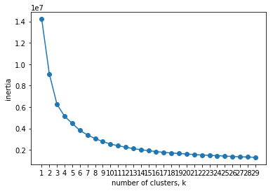

```python
df_orig = df_orig.drop(columns="anomalyIF")
df_Elbow = df_orig
ks = range(1, 30)
inertias = []

for k in ks:
    # Create a KMeans instance with k clusters: model
    model = KMeans(n_clusters=k)
    # Fit model to samples
    model.fit(df_Elbow)
     # Append the inertia to the list of inertias
    inertias.append(model.inertia_)

# Plot ks vs inertias
plt.plot(ks, inertias, '-o')
plt.xlabel('number of clusters, k')
plt.ylabel('inertia')
plt.xticks(ks)
plt.show()
```

#### Replace String text for Operating and Non-Operating Hours to binary values (1/0)

```python
columns = ['OpHours']

for col in columns:
    df_orig[col].replace({'Non-Operating Hours':'N', 'Operating Hours':'Y'}, inplace=True)
    df_orig[col].replace(to_replace=dict(Y=1, N=0), inplace=True)
```

#### Set Timestamp as Index of the dataframe

```python
df_orig = df_orig.set_index('Timestamp')
```

#### Run K-means cluster on the dataframe using 9 clusters as obtained from the Elbow plot

```python
df_KMeans_9 = df_orig
df1 = np.array(df_KMeans_9)

model = KMeans(n_clusters=9)
model.fit(df1)
y_kmeans = model.predict(df1)
len(y_kmeans)
```

```
8628
```

#### New column ClusterLabels is added to the dataframe with cluster values 0-8

```python
df_KMeans_9['ClusterLabels'] = Series(y_kmeans,index=df_KMeans_9.index)
df_KMeans_9.ClusterLabels.unique()
```

```
array([4, 3, 6, 1, 0, 7, 2, 5, 8], dtype=int64)
```

```python
df_KMeans_9.to_excel('AHUData_Labelled_9Clusters.xlsx')
```

```python
df_KMeans_9.head()
```

| Timestamp | CompAmps | Dat_SetPt | Discharge_Temp | DuctStatic_SetPt | DuctStatic | East_Temp | Fan_Hz_call | Mixed_Temp | NorthTemp | Reset_Sensor | ... | SupplyFanStatus | VAVEnableRelayStatus | VAVHeatEnableStatus | Loader1sTATUS | UnoccupiedLimit | log_econ_pos | DayOfTheWeek | WeekDay | OpHours | ClusterLabels |
| --- | --- | --- | --- | --- | --- | --- | --- | --- | --- | --- | --- | --- | --- | --- | --- | --- | --- | --- | --- | --- | --- |
| 2016-08-01 00:00:00 | 0 | 55.0 | 75.7 | 1.0 | 0.91 | 73.2 | 20 | 77.7 | 77.5 | 74.2 | ... | 1 | 1 | 0 | 0 | 0 | 1.791759 | 0 | 1 | 0 | 4 |
| 2016-08-01 01:00:00 | 0 | 55.0 | 75.4 | 1.0 | 0.08 | 77.6 | 20 | 77.6 | 77.4 | 77.7 | ... | 0 | 0 | 0 | 0 | 0 | 0.000000 | 0 | 1 | 0 | 4 |
| 2016-08-01 02:00:00 | 0 | 55.0 | 77.0 | 1.0 | 0.08 | 78.5 | 20 | 77.6 | 77.4 | 78.7 | ... | 0 | 0 | 0 | 0 | 0 | 0.000000 | 0 | 1 | 0 | 4 |
| 2016-08-01 03:00:00 | 60 | 55.0 | 54.0 | 1.0 | 1.00 | 70.6 | 20 | 77.6 | 77.4 | 73.4 | ... | 1 | 1 | 0 | 0 | 0 | 0.000000 | 0 | 1 | 0 | 3 |
| 2016-08-01 04:00:00 | 47 | 55.0 | 59.7 | 1.0 | 1.06 | 71.2 | 20 | 77.9 | 77.3 | 73.3 | ... | 1 | 1 | 0 | 0 | 0 | 0.000000 | 0 | 1 | 0 | 3 |

5 rows × 28 columns

```python
df_IF['ClusterLabels'].value_counts()
```

```
3    1271
0    1256
4    1219
8    1118
5     924
2     778
6     717
1     711
7     634
Name: ClusterLabels, dtype: int64
```

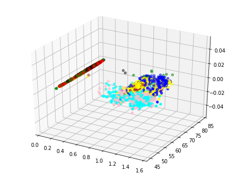

```python
from mpl_toolkits.mplot3d import Axes3D
fig = plt.figure(figsize=(8, 6))
ax = fig.add_subplot(111, projection='3d')
colors = {0:'red', 1:'blue', 2:'green', 3:'pink', 4:'black',5:'orange', 6:'cyan', 7:'yellow', 8:'brown'}
ax.scatter(list(df_IF.DuctStatic.values),list(df_IF.Discharge_Temp.values), c=df_IF['ClusterLabels'].apply(lambda x: colors[x]))
#ax.scatter(list(df_IF.CompAmps.values),list(df_IF.Discharge_Temp.values), c=df_IF['ClusterLabels'].apply(lambda x: colors[x]))
plt.show()
```

#### Visualization of 9 clusters in a scatter plot of Ductstatic and Discharge Temperature

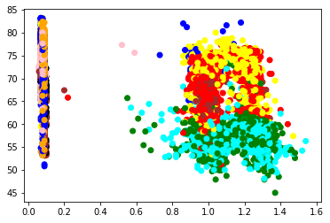

```python
fig, ax = plt.subplots()
#df_KMeans_5 = df_KMeans_5.drop(columns= ['index'])
#df_IF = df_IF.reset_index()
#df_KMeans_5
#df_KMeans_5 = df_KMeans_5.set_index(['Timestamp'])
colors = {0:'red', 1:'blue', 2:'green', 3:'pink', 4:'black',5:'orange', 6:'cyan', 7:'yellow', 8:'brown'}
ax.scatter(list(df_IF.DuctStatic.values),list(df_IF.Discharge_Temp.values), c=df_IF['ClusterLabels'].apply(lambda x: colors[x]))
#ax.scatter(list(df_IF.CompAmps.values),list(df_IF.Discharge_Temp.values), c=df_IF['ClusterLabels'].apply(lambda x: colors[x]))
plt.show()
```

#### Run Isolation Forest for anomaly detection using contamination factor 0.01 with 9 clusters which returns 87outliers

```python
#columns = [ 'CompAmps','Dat_SetPt','Discharge_Temp','DuctStatic_SetPt','DuctStatic', 'East_Temp','Fan_Hz_call','Mixed_Temp','NorthTemp','Reset_Sensor','Return_temp','South_Temp','Space_Temp','West_Temp','Outside_Air_Temp','Outside_Rel_Humidity','CompRelayStatus','Loader2Status','SupplyFanStatus','VAVEnableRelayStatus','VAVHeatEnableStatus','Loader1sTATUS','UnoccupiedLimit','log_econ_pos','DayOfTheWeek','WeekDay','OpHours']

#df_KMeans_9 = df_KMeans_9.drop(columns='anomalyIF')
clf = IsolationForest( max_samples=8628, contamination=0.01)
df_IF = df_KMeans_9
# min_max_scaler = preprocessing.StandardScaler()
# np_scaled = min_max_scaler.fit_transform(df_IF)
# df_normalized = pd.DataFrame(np_scaled)
clf.fit(df_IF)
predict  = pd.Series(clf.predict(df_IF))
predict = predict.map({1:0, -1:1})
print(predict.value_counts())
predict.count()
```

```
0    8541
1      87
dtype: int64
```

```
8628
```

```python
df_IF.to_excel('AHUData_Weekday_Cluster_Anomaly.xlsx')
```

#### Anomaly column got added to the dataframe

```python
df_IF.head()
```

|  | Timestamp | CompAmps | Dat_SetPt | Discharge_Temp | DuctStatic_SetPt | DuctStatic | East_Temp | Fan_Hz_call | Mixed_Temp | NorthTemp | ... | VAVEnableRelayStatus | VAVHeatEnableStatus | Loader1sTATUS | UnoccupiedLimit | log_econ_pos | DayOfTheWeek | WeekDay | OpHours | ClusterLabels | anomaly |
| --- | --- | --- | --- | --- | --- | --- | --- | --- | --- | --- | --- | --- | --- | --- | --- | --- | --- | --- | --- | --- | --- |
| 0 | 2016-08-01 00:00:00 | 0 | 55.0 | 75.7 | 1.0 | 0.91 | 73.2 | 20 | 77.7 | 77.5 | ... | 1 | 0 | 0 | 0 | 1.791759 | 0 | 1 | 0 | 0 | 0 |
| 1 | 2016-08-01 01:00:00 | 0 | 55.0 | 75.4 | 1.0 | 0.08 | 77.6 | 20 | 77.6 | 77.4 | ... | 0 | 0 | 0 | 0 | 0.000000 | 0 | 1 | 0 | 0 | 0 |
| 2 | 2016-08-01 02:00:00 | 0 | 55.0 | 77.0 | 1.0 | 0.08 | 78.5 | 20 | 77.6 | 77.4 | ... | 0 | 0 | 0 | 0 | 0.000000 | 0 | 1 | 0 | 0 | 0 |
| 3 | 2016-08-01 03:00:00 | 60 | 55.0 | 54.0 | 1.0 | 1.00 | 70.6 | 20 | 77.6 | 77.4 | ... | 1 | 0 | 0 | 0 | 0.000000 | 0 | 1 | 0 | 8 | 0 |
| 4 | 2016-08-01 04:00:00 | 47 | 55.0 | 59.7 | 1.0 | 1.06 | 71.2 | 20 | 77.9 | 77.3 | ... | 1 | 0 | 0 | 0 | 0.000000 | 0 | 1 | 0 | 8 | 0 |

5 rows × 30 columns

#### Plotting south temp to see the anomalies on montly basis

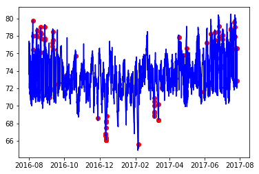

```python
fig,ax = plt.subplots()
a = df_IF.loc[df_IF['anomaly'] == 1, ['Timestamp', 'South_Temp']] #anomaly
b = a.values
ax.plot(df_IF['Timestamp'], df_IF['South_Temp'], color='blue')
ax.scatter(b[:,0],b[:,1], color='red')
plt.show()
```

#### Plotting compamps to see the anomalies

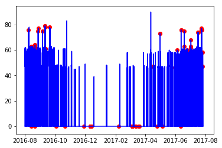

```python
fig,ax = plt.subplots()
df_IF['anomaly'] = predict.values
df_IF = df_IF.reset_index()
a = df_IF.loc[df_IF['anomaly'] == 1, ['Timestamp', 'CompAmps']] #anomaly
b = a.values
ax.plot(df_IF['Timestamp'], df_IF['CompAmps'], color='blue')
ax.scatter(b[:,0],b[:,1], color='red')
plt.show()
```

#### Plot of outliers on a scatter plot of CompAmps and Discharge Temperature . At higher values of CompAmps and low values of Discharge_temp, a few outliers are seen

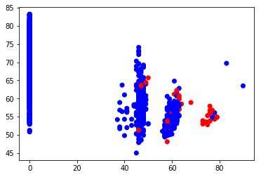

```python
# visualisation of anomaly with cluster view
fig, ax = plt.subplots()
colors = {0:'blue', 1:'red'}
ax.scatter(list(df_IF.CompAmps.values),list(df_IF.Discharge_Temp.values), c=df_IF["anomaly"].apply(lambda x: colors[x]))
plt.show()
```

#### Plot of outliers on a scatter plot of Fan Hz Call and Discharge Temperature for cluster 1

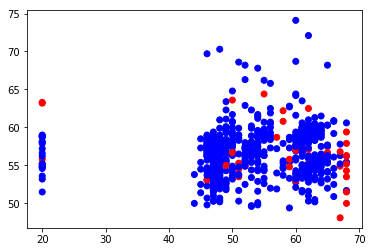

```python
df_1 = df_IF['ClusterLabels']==1
clus1 = df_IF[df_1]
#print(clus1.shape)
# visualisation of anomaly with cluster view
fig, ax = plt.subplots()
colors = {0:'blue', 1:'red'}
ax.scatter(list(clus1.Fan_Hz_call.values), list(clus1.Discharge_Temp.values), c=clus1["anomaly"].apply(lambda x: colors[x]))
plt.show()
```

#### Visualisation of anomaly with cluster view for compamp and discharge temp

#### When operating hours is 1 i.e. 6 AM to 6 PM

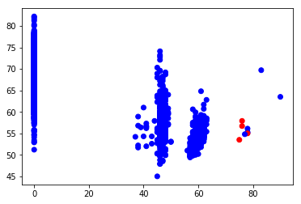

```python
df_2 = df_IF['OpHours']==1
clusOpHours = df_IF[df_2]
#print(clus1.shape)
# visualisation of anomaly with cluster view
fig, ax = plt.subplots()
colors = {0:'blue', 1:'red'}
ax.scatter(list(clusOpHours.CompAmps.values), list(clusOpHours.Discharge_Temp.values), c=clusOpHours["anomaly"].apply(lambda x: colors[x]))
plt.show()
```

#### Visualisation of anomaly with cluster view for compamp and discharge temp

#### When non operating hours is 1 i.e. 6 PM to 6 AM

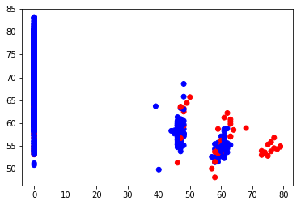

```python
df_3 = df_IF['OpHours']==0
clusNonOpHours = df_IF[df_3]
#print(clus1.shape)
# visualisation of anomaly with cluster view
fig, ax = plt.subplots()
colors = {0:'blue', 1:'red'}
ax.scatter(list(clusNonOpHours.CompAmps.values), list(clusNonOpHours.Discharge_Temp.values), c=clusNonOpHours["anomaly"].apply(lambda x: colors[x]))
plt.show()
```

#### Visualisation of anomaly with cluster view for compamp and discharge temp

#### When operating hours is 1 and its a WeekDay i.e. 6 AM to 6 PM

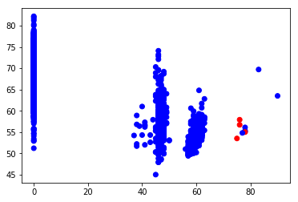

```python
df_4 = df_IF[(df_IF['WeekDay']==1) & (df_IF['OpHours']==1)]
#clusOpHours = df_IF[df_4]
#print(clus1.shape)
# visualisation of anomaly with cluster view
fig, ax = plt.subplots()
colors = {0:'blue', 1:'red'}
ax.scatter(list(df_4.CompAmps.values), list(df_4.Discharge_Temp.values), c=df_4["anomaly"].apply(lambda x: colors[x]))
plt.show()
```

#### Visualisation of anomaly with cluster view for compamp and discharge temp

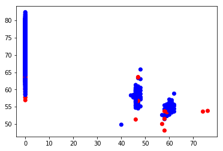

```python
df_5 = df_IF[(df_IF['WeekDay']==1) & (df_IF['OpHours']==0)]
#clusOpHours = df_IF[df_4]
#print(clus1.shape)
# visualisation of anomaly with cluster view
fig, ax = plt.subplots()
colors = {0:'blue', 1:'red'}
ax.scatter(list(df_5.CompAmps.values), list(df_5.Discharge_Temp.values), c=df_5["anomaly"].apply(lambda x: colors[x]))
plt.show()
```

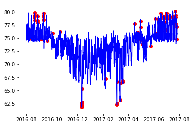

```python
fig,ax = plt.subplots()
#df_IF['anomaly'] = predict.values
#df_IF = df_IF.reset_index()
a = df_IF.loc[df_IF['anomaly'] == 1, ['Timestamp', 'NorthTemp']] #anomaly
b = a.values
ax.plot(df_IF['Timestamp'], df_IF['NorthTemp'], color='blue')
ax.scatter(b[:,0],b[:,1], color='red')
plt.show()
```

#### Visualisation of anomaly for North temp

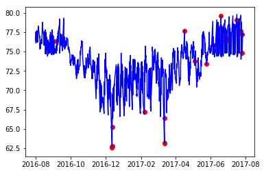

```python
df_6 = df_IF[(df_IF['WeekDay']==1) & (df_IF['OpHours']==0)]
fig,ax = plt.subplots()
#df_5['anomaly'] = predict.values
#df_IF = df_IF.reset_index()
a = df_6.loc[df_6['anomaly'] == 1, ['Timestamp', 'NorthTemp']] #anomaly
b = a.values
ax.plot(df_6['Timestamp'], df_6['NorthTemp'], color='blue')
ax.scatter(b[:,0],b[:,1], color='red')
plt.show()
```

#### Visualisation of anomaly for North temp

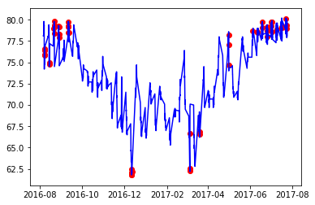

```python
df_7 = df_IF[(df_IF['WeekDay']==0) & (df_IF['OpHours']==0)]
fig,ax = plt.subplots()
#df_5['anomaly'] = predict.values
#df_IF = df_IF.reset_index()
a = df_7.loc[df_7['anomaly'] == 1, ['Timestamp', 'NorthTemp']] #anomaly
b = a.values
ax.plot(df_7['Timestamp'], df_7['NorthTemp'], color='blue')
ax.scatter(b[:,0],b[:,1], color='red')
plt.show()
```

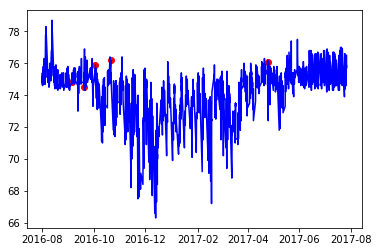

```python
df_5 = df_IF[(df_IF['WeekDay']==1) & (df_IF['OpHours']==1)]
fig,ax = plt.subplots()
#df_5['anomaly'] = predict.values
#df_IF = df_IF.reset_index()
a = df_5.loc[df_5['anomaly'] == 1, ['Timestamp', 'NorthTemp']] #anomaly
b = a.values
ax.plot(df_5['Timestamp'], df_5['NorthTemp'], color='blue')
ax.scatter(b[:,0],b[:,1], color='red')
plt.show()
```

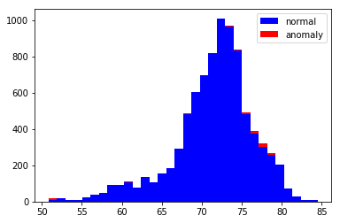

```python
a = df_IF.loc[df_IF['anomaly'] == 0, 'Return_temp']
b = df_IF.loc[df_IF['anomaly'] == 1, 'Return_temp']

fig, axs = plt.subplots()
axs.hist([a,b], bins=32, stacked=True, color=['blue', 'red'], label=['normal', 'anomaly'])
plt.legend()
plt.show()
```

#### Visualisation of anomaly for mixed temp

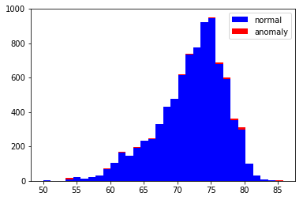

```python
a = df_IF.loc[df_IF['anomaly'] == 0, 'Mixed_Temp']
b = df_IF.loc[df_IF['anomaly'] == 1, 'Mixed_Temp']

fig, axs = plt.subplots()
axs.hist([a,b], bins=32, stacked=True, color=['blue', 'red'], label=['normal', 'anomaly'])
plt.legend()
plt.show()
```

#### Visualisation of anomaly for North temp

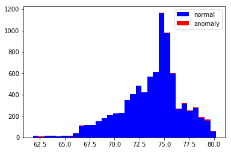

```python
a = df_IF.loc[df_IF['anomaly'] == 0, 'NorthTemp']
b = df_IF.loc[df_IF['anomaly'] == 1, 'NorthTemp']

fig, axs = plt.subplots()
axs.hist([a,b], bins=32, stacked=True, color=['blue', 'red'], label=['normal', 'anomaly'])
plt.legend()
plt.show()
```